# Лабораторная работа №11

Настройка безопасного удалённого доступа по протоколу SSH

Цыкунова Екатерина Михайловна

1132246732@rudn.ru

Российский университет дружбы народов

2026-10-31

# Цели и задачи работы

## Цель лабораторной работы

Целью данной работы является приобретение практических навыков настройки безопасного удалённого доступа к серверу по протоколу SSH, управления правами пользователей, настройки дополнительных портов, аутентификации по ключу, организации SSH-туннелей и автоматизации конфигурации SSH-сервера с помощью Vagrant.

## Задачи лабораторной работы

- ограничить удалённый доступ пользователями vagrant и emcikunova;
- настроить подключение по SSH через дополнительный порт 2022;
- настроить аутентификацию по SSH-ключу;
- организовать SSH-туннель с перенаправлением TCP-портов;
- настроить перенаправление графического интерфейса X11;

# Процесс выполнения лабораторной работы

## Проверяю подключение по SSH от имени root

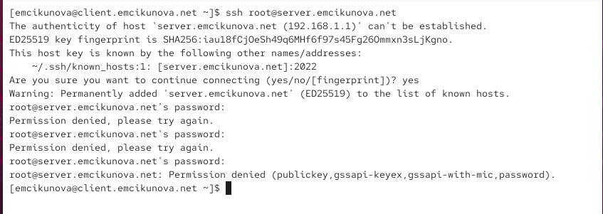

Попытка подключения к серверу по SSH от имени root

## Запрещаю удалённый доступ пользователю root

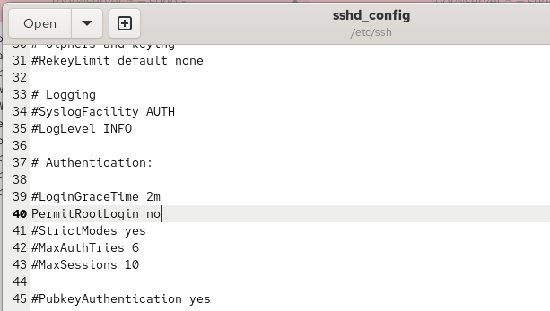

Установка параметра PermitRootLogin no в конфигурации SSH

## Проверяю запрет подключения пользователя root

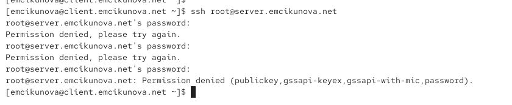

Повторная попытка подключения по SSH и отказ в доступе

## Проверяю подключение пользователя emcikunova

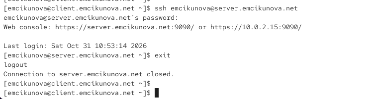

Успешное подключение к серверу по SSH от имени emcikunova

## Ограничиваю список пользователей SSH

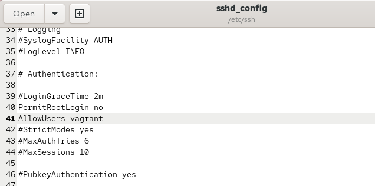

Настройка параметра AllowUsers vagrant в конфигурационном файле sshd_config

## Проверяю ограничение удалённого доступа

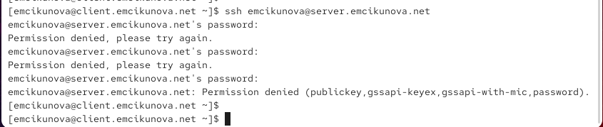

Отказ в подключении пользователя emcikunova после ограничения AllowUsers

## Разрешаю SSH-доступ пользователю emcikunova

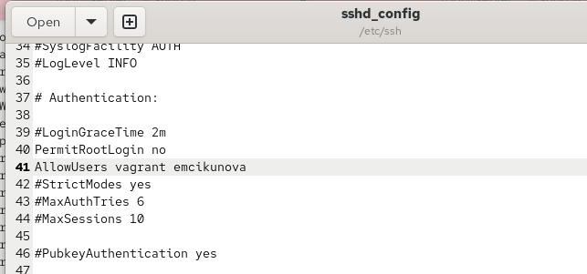

Добавление пользователей vagrant и emcikunova в параметр AllowUsers

## Проверяю подключение после изменения AllowUsers

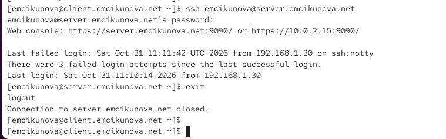

Успешное SSH-подключение пользователя emcikunova после изменения конфигурации

## Настраиваю дополнительные порты SSH

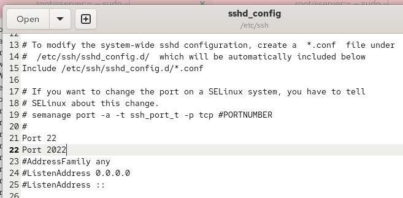

Добавление портов 22 и 2022 в конфигурационный файл sshd_config

## Проверяю работу SSH на порту 2022

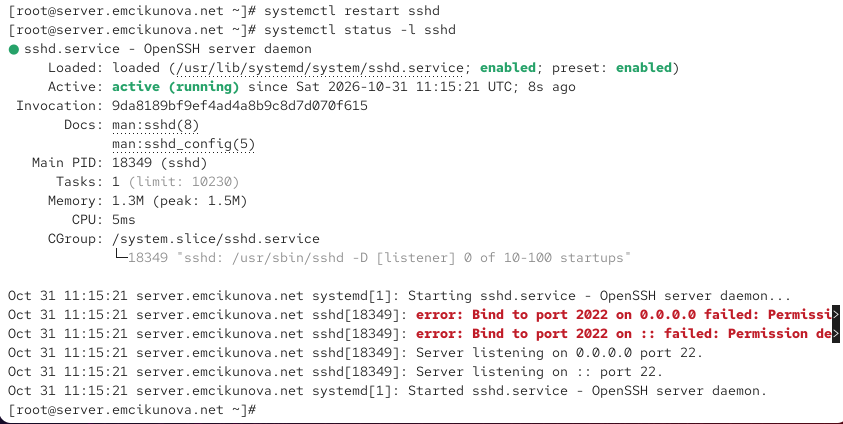

Проверка состояния sshd и сообщение об ошибке привязки к порту 2022

## Анализирую сообщения SELinux

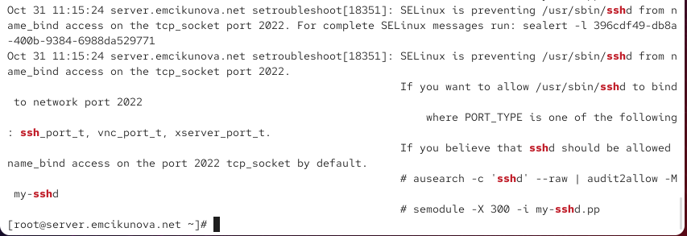

Сообщения системного журнала о блокировке TCP-порта 2022 политикой SELinux

## Разрешаю порт 2022 в SELinux и межсетевом экране

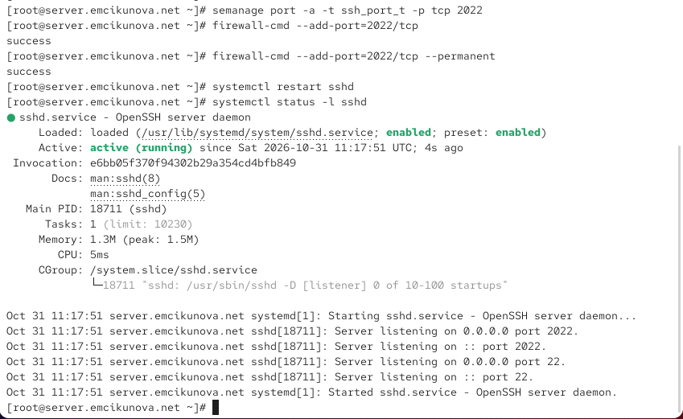

Настройка SELinux, открытие TCP-порта 2022 и проверка состояния SSH-сервера

## Проверяю SSH-соединение через порт 22

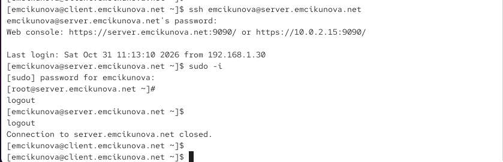

Подключение к серверу через порт 22 и получение прав суперпользователя

## Проверяю SSH-соединение через порт 2022

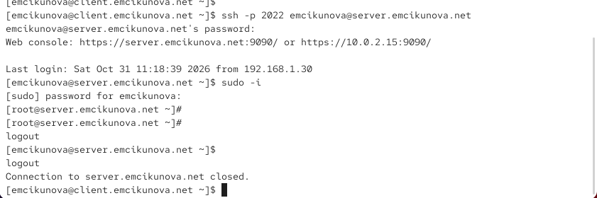

Подключение к серверу через порт 2022 и получение прав суперпользователя

## Разрешаю аутентификацию по SSH-ключу

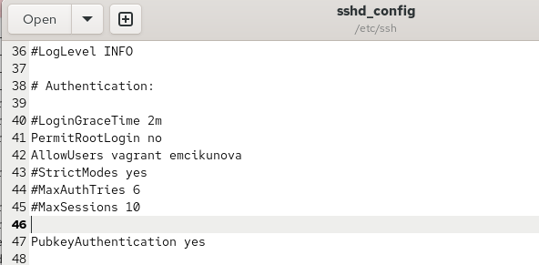

Настройка параметра PubkeyAuthentication yes в конфигурации SSH

## Генерирую пару SSH-ключей на клиенте

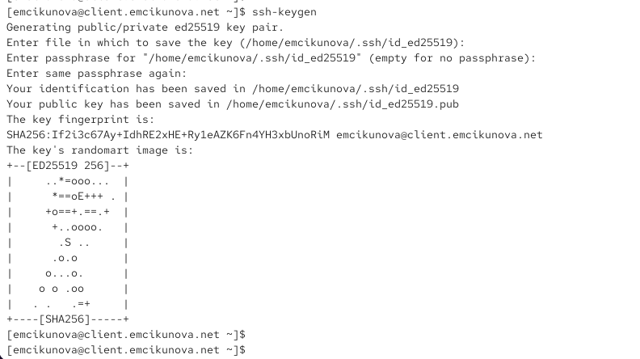

Создание открытого и закрытого ключей с помощью ssh-keygen

## Копирую открытый ключ на сервер

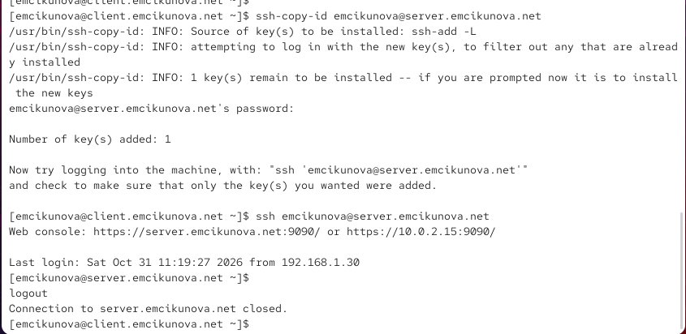

Копирование SSH-ключа с помощью ssh-copy-id и проверка подключения без пароля

## Создаю SSH-туннель

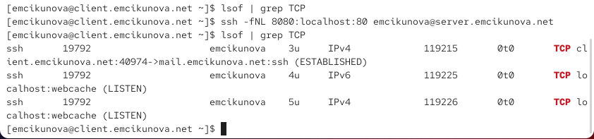

Перенаправление локального порта 8080 на порт 80 сервера и проверка TCP-соединений

## Проверяю работу SSH-туннеля в браузере

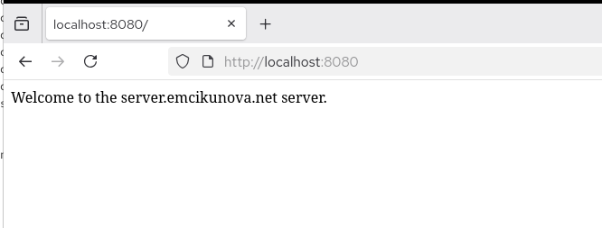

Открытие страницы Welcome to the server.emcikunova.net server через localhost:8080

## Выполняю удалённые консольные команды

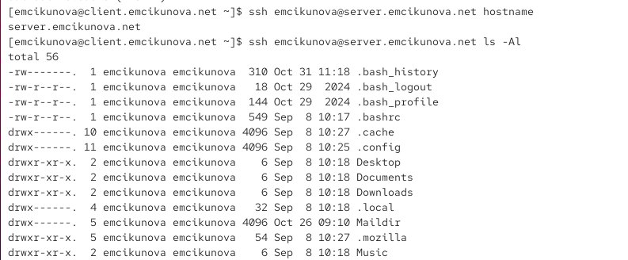

Получение имени сервера командой hostname и просмотр файлов через SSH

## Просматриваю почтовый ящик через SSH

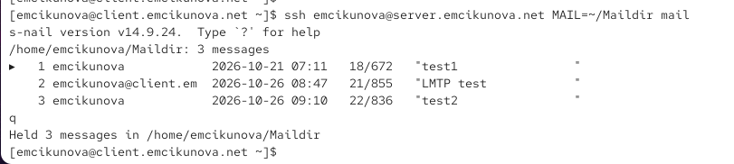

Удалённый запуск почтовой программы mail и просмотр сообщений на сервере

## Настраиваю перенаправление X11

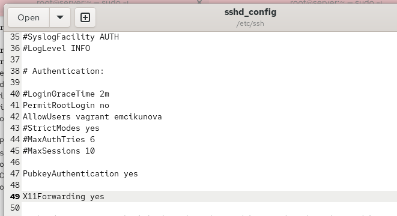

Установка параметра X11Forwarding yes в конфигурационном файле SSH

## Проверяю запуск графического приложения через SSH

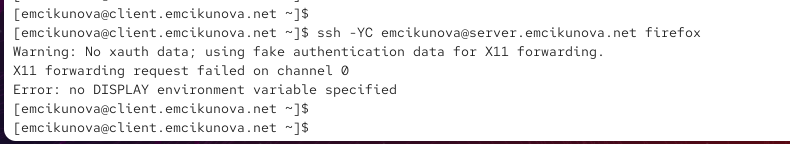

Попытка запуска Firefox через X11Forwarding и сообщения об ошибке DISPLAY

## Подготавливаю конфигурацию SSH для Vagrant

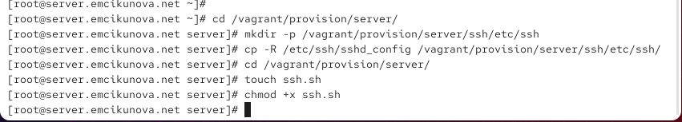

Создание каталога для конфигурации SSH и исполняемого скрипта ssh.sh

## Создаю скрипт автоматической настройки SSH

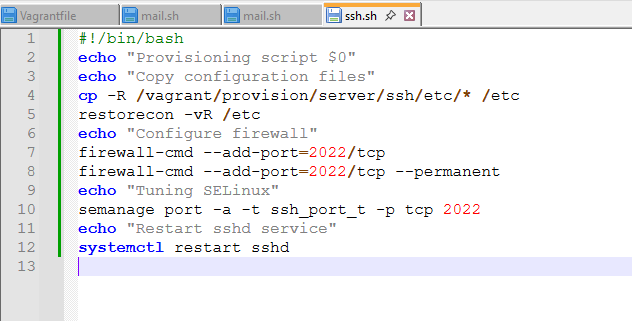

Добавление команд настройки SSH, SELinux и межсетевого экрана в скрипт ssh.sh

# Результаты лабораторной работы

## Вывод

В ходе лабораторной работы я настроила безопасный удалённый доступ к серверу `server.emcikunova.net` по протоколу SSH. Запретила подключение пользователю `root` и ограничила доступ пользователями `vagrant` и `emcikunova`.

Настроила работу SSH-сервера через порты `22` и `2022`, разрешила дополнительный порт в SELinux и межсетевом экране. Настроила аутентификацию по SSH-ключу и проверила подключение без ввода пароля.

Организовала SSH-туннель с перенаправлением TCP-портов и проверила удалённое выполнение консольных команд. Включила поддержку X11Forwarding, однако запуск графического приложения завершился ошибкой из-за отсутствия настроенного дисплея.

Создала исполняемый скрипт `ssh.sh` для автоматизации настройки SSH-сервера во внутреннем окружении виртуальной машины Vagrant.